# Practical Machine Learning - Week 4

## Regularized Regression

1. Fit a regression model
2. Penalize (or shrink) large coefficients

**Pros:**

1. Can help with the bias variance tradeoff
2. Can help with the model selection

**Cons:**

1. Computational demanding on large datasets
2. Does not perform as well as Random Forests and boosting

In caret methods are:

- ridge
- lasso
- relaxo

## Combining Predictors

- Combine classifiers by averaging/voting
- Improve accuracy
- Reduce interpretability
- Boosting, bagging, random forests are variants on this theme

Approaches:

1. Bagging, boosting, random forests
   - Usually combine similar classifiers
2. Combining different classifiers
   - Model stacking
   - Model ensambling

### Model Stacking

Data

```r
library(ISLR)
library(data.table)
library(ggplot2)
library(caret)
library(magrittr)

data("Wage"); setDT(Wage)
Wage[, logwage := NULL]

# Create training set and validation set
idx_build <- createDataPartition(Wage$wage, p = 0.7, list = FALSE)
validation <- Wage[-idx_build]
train_idx <- createDataPartition(Wage[idx_build, wage], p = 0.7, list = FALSE)
training <- Wage[idx_build][train_idx]
testing <- Wage[idx_build][-train_idx]
```

Build two different models

```r
mod1 <- train(wage ~., method = "glm", data = training)
mod2 <- train(wage ~., method = "rf", data = training,
              trControl = trainControl(method = "cv"),
              number = 3)

pred1 <- predict(mod1, newdata = testing)
pred2 <- predict(mod2, newdata = testing)
```

Fit a model that **combine the predictors**

```r
pred_dt <- data.table(
  pred1,
  pred2,
  wage = testing$wage
)

comb_mod <- train(wage ~ ., method = "gam", data = pred_dt)
comb_pred <- predict(comb_mod, pred_dt)
```

Tesing errors

```r
# model 1
(pred1 - testing$wage)^2 %>% sum %>% sqrt()
```

```
## [1] 858.0813
```

```r
# model 1
(pred2 - testing$wage)^2 %>% sum %>% sqrt()
```

```
## [1] 893.6804
```

```r
# combined model
(comb_pred - testing$wage)^2 %>% sum %>% sqrt()
```

```
## [1] 852.0792
```

Predict on validation dataset

```r
pred_val_1 <- predict(mod1, validation)
pred_val_2 <- predict(mod2, validation)
pred_val_dt <- data.table(pred1 = pred_val_1, pred2 = pred_val_2)
comb_pred_val <- predict(comb_mod, pred_val_dt)

# Evaluation on validation
(comb_pred_val - validation$wage)^2 %>% sum %>% sqrt
```

```
## [1] 1025.047
```

## Forecasting (for time temporal data, spatial data)

- Goal: predict one or more observations in the future

```r
library(forecast)
library(quantmod)
GOOG <- getSymbols("GOOG", auto.assign = FALSE)
class(GOOG)
```

```
## [1] "xts" "zoo"
```

```r
head(GOOG)
```

```
##            GOOG.Open GOOG.High GOOG.Low GOOG.Close GOOG.Volume
## 2007-01-03   232.130   237.440  229.694   232.9220    15470700
## 2007-01-04   233.624   241.071  233.301   240.7277    15834200
## 2007-01-05   240.349   242.840  238.162   242.6853    13795600
## 2007-01-08   242.934   244.020  240.200   240.8871     9544400
## 2007-01-09   241.819   243.213  239.702   241.8435    10803000
## 2007-01-10   241.311   245.853  240.120   243.8161    11981700
##            GOOG.Adjusted
## 2007-01-03      232.9220
## 2007-01-04      240.7277
## 2007-01-05      242.6853
## 2007-01-08      240.8871
## 2007-01-09      241.8435
## 2007-01-10      243.8161
```

Summarize monthly and store as time series

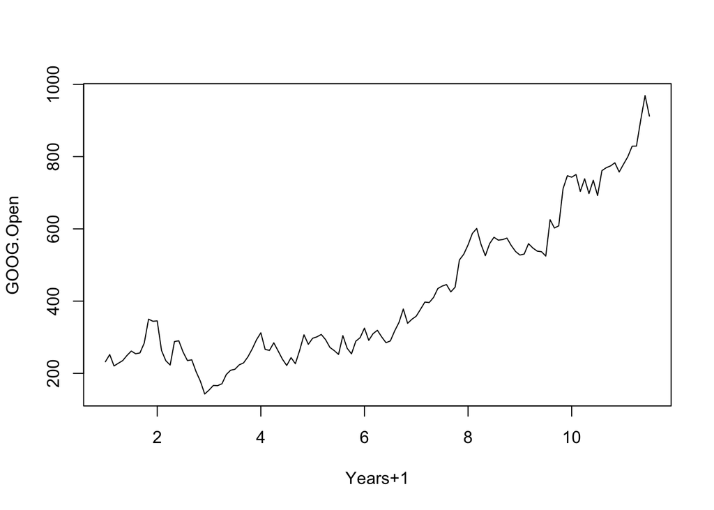

```r
mGOOG <- to.monthly(GOOG)
goog_open <- Op(mGOOG)
ts1 <- ts(goog_open, frequency = 12)
plot(ts1, xlab = "Years+1")
```

Time series decomposition

- Trend
- Seasonal
- Cyclic

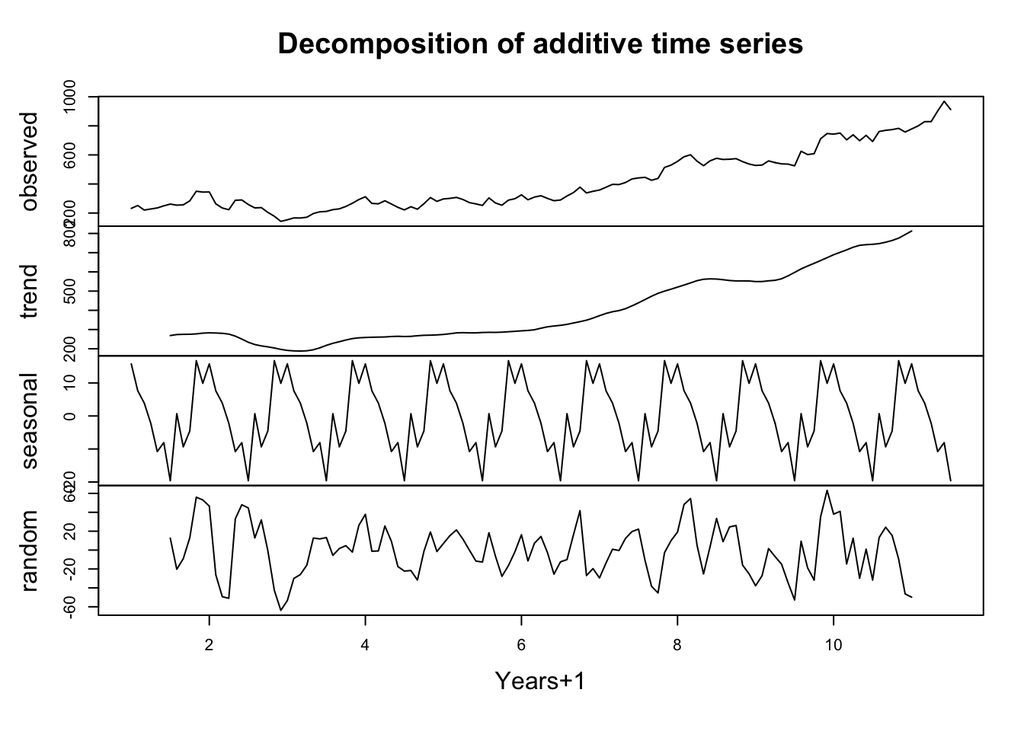

```r
plot(decompose(ts1), xlab = "Years+1")
```

Training and test sets

```r
ts1_train <- window(ts1, start = 1, end = 5)
ts1_test <- window(ts1, start = 5, end = 7-0.01)
```

**Simple moving average**

$$Y_t = \frac{1}{2*k+1}\sum_{ j=-k }^{ k }{ y_{t+j} }$$

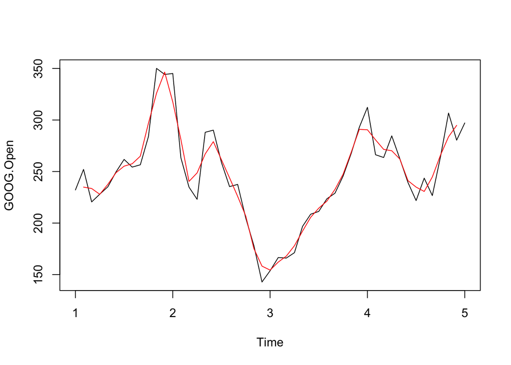

```r
plot(ts1_train)
lines(ma(ts1_train, 3), col = "red")
```

**Exponential Smoothing**

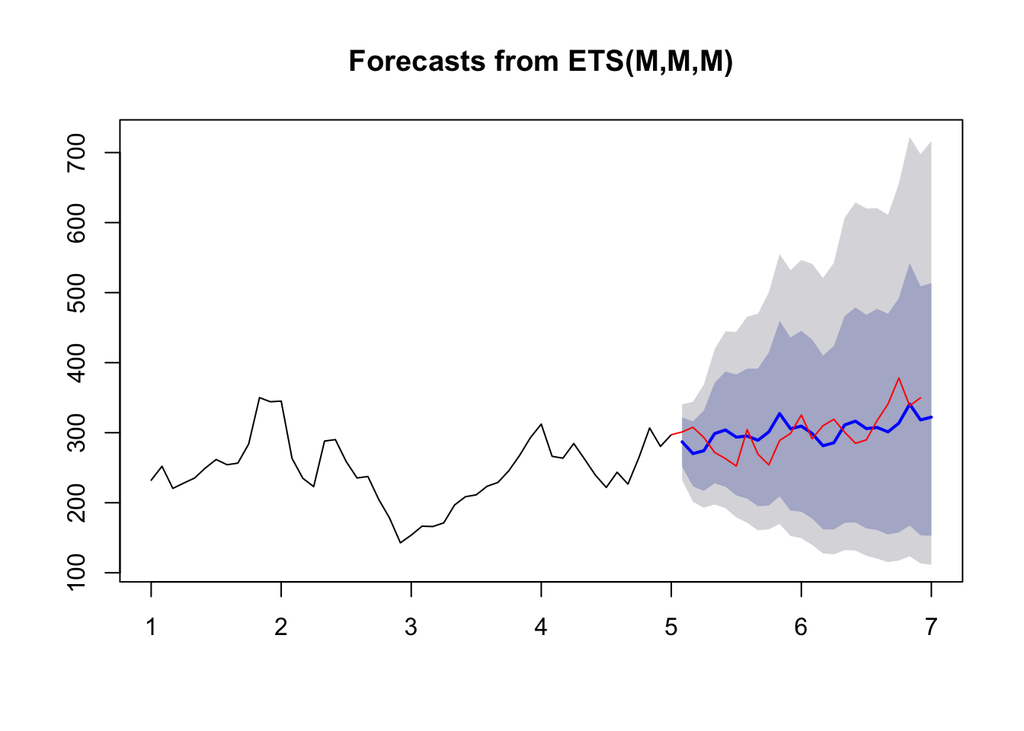

```r
ets1 <- ets(ts1_train, model = "MMM")
fcast <- forecast(ets1)
plot(fcast); lines(ts1_test, col = "red")
```

Accuracy

```r
accuracy(fcast, ts1_test)
```

```
##                      ME     RMSE      MAE        MPE     MAPE      MASE
## Training set -0.5214529 24.63189 19.50446 -0.7301588 8.082383 0.3078515
## Test set      0.6261855 30.03867 25.77433 -0.6434422 8.631959 0.4068130
##                   ACF1 Theil's U
## Training set 0.1263095        NA
## Test set     0.4610975  1.220331
```

## Unsupervised Prediction

K-means

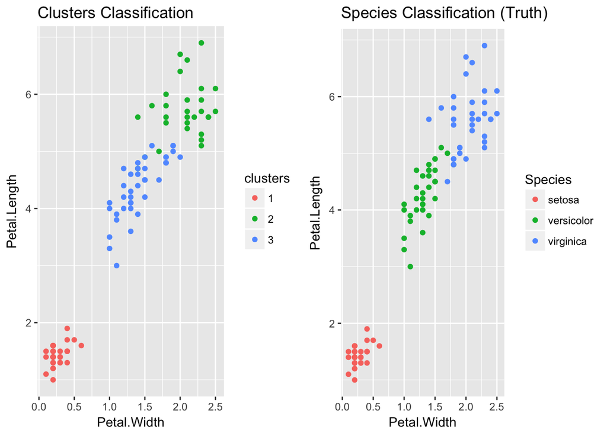

```r
library(data.table)
library(caret)
library(ggplot2)
library(gridExtra)

data("iris")
setDT(iris)

# create training and test sets
inTrain <- createDataPartition(y=iris$Species,p=0.7, list=FALSE)
training <- iris[inTrain,]; testing <- iris[-inTrain,]

# perform k-means clustering for the data without the Species information
# Species = what the true clusters are
kMeans1 <- kmeans(training[, -"Species"], centers=3)
# add clusters as new variable to training set
training$clusters <- as.factor(kMeans1$cluster)

# plot clusters vs Species classification
p1 <- qplot(Petal.Width,Petal.Length,colour=clusters,data=training) +
    ggtitle("Clusters Classification")
p2 <- qplot(Petal.Width,Petal.Length,colour=Species,data=training) +
    ggtitle("Species Classification (Truth)")
grid.arrange(p1, p2, ncol = 2)
```

# Quiz

```r
library(ElemStatLearn)
library(data.table)
data(vowel.train); setDT(vowel.train)
data(vowel.test); setDT(vowel.test)

vowel.train[, y := as.factor(as.character(y))]
vowel.test[, y := as.factor(as.character(y))]
```